# Accessible overview on predicting initial math success for first time freshmen

Bill Prisbrey

2025-11-07

# EXECUTIVE SUMMARY

### *PURPOSE:* **The purpose of this document is to describe recent efforts in predicting grade performance for initial math courses for first time freshmen based on minimal data available at the time of admission.**

### *EXECUTIVE SUMMARY:*

# DATA

- *Demographics data* describing first time freshmen include age, sex, first generation status, and ethnicity.
- *High school data* including high school GPA, number of AP credits, and whether the high school was public or private.
- *Test scores* from the ACT including Math, English, Science, and Comprehensive. (Note: SAT test scores were not used, and students who did not submit an ACT test score were excluded.)
- *University information* included the name of the course, the course level, residence status, Pell grant eligibility, cohort year (2005 to 2024), class year (2005 to 2025), years from the cohort date (always in the fall) until the first term math courses were taken, season, and honors status.
- *Derived features* included calculating a kind of z-score for the high school GPA and ACT math test scores and combining them into a single “distance” measure.

# ANALYSES CONDUCTED

- *Descriptive* analyses investigated how key variables changed over the time span of the study.
- *Predictive* analyses modeled predictors of grade performance.
- *Time series* analyses investigated predictive model accuracy over time by generating a predictive model per year. Grade performance and course selection were both modeled.

# KEY FINDINGS

### *Variable importance:*

- High school GPA, ACT Math test scores, and their derivative features were consistently the most important predictors.
- ACT Math test scores, followed by “distance”, were the most important features for predicting course selection.
- High school GPA, distantly followed by the high school GPA z-score, “distance”, and ACT Math z-score, were the most important features for predicting grade performance.

### *Over time:*

- *Course selection accuracy declined while grade performance accuracy improved.*
  - Predictive accuracy for course selection started with a Kappa of ~0.45 in 2008-2010 and declined to values of ~0.06-0.07 in 2023-2024. This suggests there was initially a moderate relationship between the predictors and course selection that declined until there was essentially no relationship in 2023-2024.
- Conversely, predictive accuracy for grade performance started with an R-squared value of ~0.2 in 2007-2010 and improved to a predictive accuracy of ~0.28 in 2024.
- *The environment is dynamic over time.*
- Grade inflation or grade compression was observed over the time period. The proportion of students receiving an ‘A’ increased from about 20% in 2005 to ~33% in 2024.
- ACT test score submission rates have decreased dramatically, from roughly 90% until 2016 to only 30% for enrollees in high volume math courses.
- The mix of courses selected changed, from Math 1010 as the dominant choice until 2017 and Math 1090 as the highest enrolled course in 2024.
- Anomalies and discontinuities in models and predictors were observed in the years 2011, 2020, and 2023-2024.

# DISCUSSION

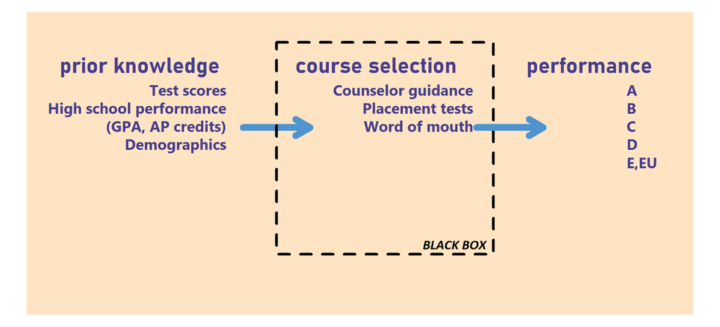

```r
displayPipeline()
```

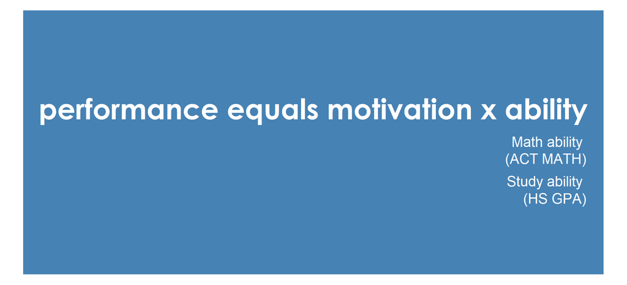

```r
displayPerformance()
```

The important variables are consistent with the theory that performance is an outcome of motivation and ability, where ACT Math represents math ability and high school GPA represents studiousness or “study ability.”  
The collapse of accuracy in predicting course selection may suggest a current kind of “free-for-all” in course enrollment. Discussing the current situation and other historical trends with an instructor familiar with the history of the math department could be insightful.

# CONCLUSIONS

# POSSIBLE NEXT STEPS

- **Discuss this report** and findings with instructors in the math department familiar with the history and current situation.
- **Include concurrent variables** such as number of credits, concurrent courses and their difficulty, initial course grades on quizzes, homework, and tests, utilization of tutoring services, and participation in study groups.
- **Develop gentle guidelines** for course recommendations based on ACT math test scores and high school GPA